# Crude oil production around the world(Top 10) between 2000-2017

szzwt

2024-04-26

```r
#Import packages
library(tidyverse)
library(ggplot2)
library(gganimate)
library(readr)
```

## Data Origins

The data is from https://www.kaggle.com/code/caesarmario/forecasting-crude-oil-value/input, which data was collected from OCED(https://data.oecd.org/energy/crude-oil-production.htm).

```r
# load data
data <- read.csv("data/crudeoil_production.csv")

# show 5 rows of data
head(data, n = 5)
```

```
##   LOCATION INDICATOR SUBJECT MEASURE FREQUENCY TIME Value Flag.Codes
## 1      AUS   OILPROD     TOT    KTOE         A 1960    NA          L
## 2      AUS   OILPROD     TOT    KTOE         A 1961    NA          L
## 3      AUS   OILPROD     TOT    KTOE         A 1962    NA          L
## 4      AUS   OILPROD     TOT    KTOE         A 1963    NA          L
## 5      AUS   OILPROD     TOT    KTOE         A 1964    NA          L
```

## Research Questions

visualising data on the amount of oil produced in different countries can visually compare how each country performs in terms of oil production. This can help people understand the distribution of the global oil industry and the importance of each country in energy production. It also can be used to study the relation ship between the exploitation of natural resources resource and some other factors such as economy, environment.

## Data Preparation

After loading data, there are many redudant data that need to be filtered.

Here we create a ranking veriable to store the rank each year.

```r
# filter the data that is unknown. the TIME >= 2000

filtered_data <- data[data $ Flag.Codes != "L" & data$TIME >= 2000, ]

# group data by TIME
# arrange the data in order by value
# only remain the top 10

data_top10 <- filtered_data %>%
  group_by(TIME) %>%
  arrange(TIME, desc(Value)) %>%
  mutate(ranking = row_number()) %>%
  filter(ranking <= 10)
head(data_top10,10)
```

```
## # A tibble: 10 × 9
## # Groups:   TIME [1]
##    LOCATION INDICATOR SUBJECT MEASURE FREQUENCY  TIME   Value Flag.Codes ranking
##    <chr>    <chr>     <chr>   <chr>   <chr>     <int>   <dbl> <chr>        <int>
##  1 WLD      OILPROD   TOT     KTOE    A          2000  3.41e6 ""               1
##  2 G20      OILPROD   TOT     KTOE    A          2000  1.83e6 ""               2
##  3 OECD     OILPROD   TOT     KTOE    A          2000  8.96e5 ""               3
##  4 SAU      OILPROD   TOT     KTOE    A          2000  4.10e5 ""               4
##  5 OEU      OILPROD   TOT     KTOE    A          2000  3.22e5 ""               5
##  6 RUS      OILPROD   TOT     KTOE    A          2000  3.13e5 ""               6
##  7 USA      OILPROD   TOT     KTOE    A          2000  2.98e5 ""               7
##  8 IRN      OILPROD   TOT     KTOE    A          2000  1.97e5 ""               8
##  9 VEN      OILPROD   TOT     KTOE    A          2000  1.71e5 ""               9
## 10 NOR      OILPROD   TOT     KTOE    A          2000  1.64e5 ""              10
```

## graph or graphs

An animation consist of many static pictures, so that is what to do before animate.

After data was prepared, plot the static plots for all years by ggplot2

```r
# plot the static data of each year
  ## set the axis, text and label of the plot
  ## filp the axis
  ## theme layout

plot <- data_top10 %>%
  ggplot() +
  geom_col(aes(ranking, Value, fill = LOCATION)) +
  geom_text(aes(ranking, Value,label = as.character(Value)), hjust = -0.1) +
  geom_text(aes(ranking, y=0, label = LOCATION), hjust = 1.1) +
  geom_text(aes(x = 10, y = max(Value) , label = as.factor(TIME)), vjust = 0.2, alpha = 0.5,  col = "gray", size = 20) +
  scale_y_continuous(label = function(x) paste(round(x / 1000, 2), " k"))+
  coord_flip(clip = "off", expand = FALSE) + scale_x_reverse() +
  theme_minimal() +
  theme(
    panel.grid = element_blank(),
    legend.key.size = unit(0.3, "cm"),
    legend.position = c(1.0, 0.3),
    legend.title=element_blank(),
    axis.ticks.y = element_blank(),
    axis.title.y = element_blank(),
    axis.text.y = element_blank(),
    plot.margin = margin(1, 4, 1, 3, "cm"),
    plot.title = element_text(face = "bold", hjust = 0.5),
  ) +
  guides(fill = guide_legend(ncol = 2))
```

The final step is make plots into animation by gganimate

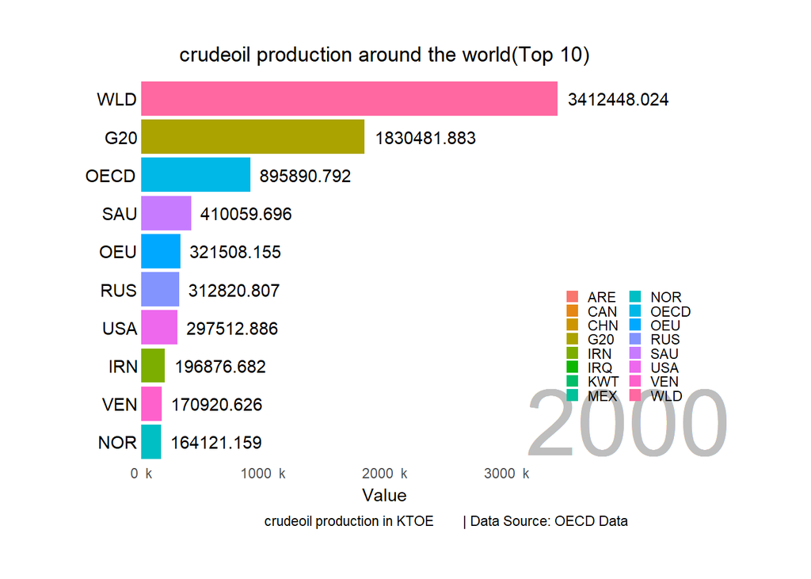

```r
# animation and save
 ## animate change by TIME
 ## smoothing treatment

plot_transition <- plot+transition_states(TIME, state_length = 0, transition_length = 2) +
  labs(title = 'crudeoil production around the world(Top 10)',
       caption  = "crudeoil production in KTOE        | Data Source: OECD Data",
      ) +
  enter_fade() +
  exit_fade() +
  ease_aes('quadratic-in-out')

animate(plot_transition,renderer=gifski_renderer("gif/crudeoil_production_visualization.gif"))
```

## Summary

In this project, the most things i have learned is that how to visualize the data dynamically. Using gganimate makes it easier to show the time scale in a more convenient way. I also learned how to control the layout by Control parameters and variables in the function.

If i have more time to continue my project, i will add some of the data of other energy sources. Overmore, if i can get the data that can shows the economy situation of each country, i also can find relationship between economy and the production of energy sources, and how revelant they are.

## Reference

Data source: Kaggle-https://www.kaggle.com/code/caesarmario/forecasting-crude-oil-value/input